# Risk Factors Associated with Low Infant Birth Weight

Abderrezzaq KADOUCHE

## **Introduction**

Low birth weight (LBW), defined by the World Health Organization as a birth weight below 2500 grams, remains one of the strongest and most consistent predictors of neonatal morbidity and mortality.

Infants born with LBW are at elevated risk of respiratory distress, infections, neurodevelopmental impairment, and long-term chronic conditions, while also imposing substantial costs on health systems.

Understanding which maternal characteristics are associated with LBW is therefore of direct clinical and public health relevance.

## **Objective**

The primary objective of this case study is to identify maternal and pregnancy-related factors associated with the occurrence of low birth weight.

## **Study Design and Data**

The data were collected at the Baystate Medical Center, Springfield, Massachusetts, in 1986.

The dataset contains 189 observations (pregnancies) and 10 variables.

## **Variable Specifications**

- **`low`** : Indicator of birth weight less than 2.5 kg: 0 = birth weight ≥ 2.5 kg; 1 = birth weight < 2.5 kg.
- **`bwt`** : Birth weight: grams.
- **`age`** : Mother’s age: years.
- **`lwt`** : Mother’s weight at last menstrual period: pounds.
- **`race`** : Mother’s race: 1 = white; 2 = black; 3 = other.
- **`smoke`** : Smoking status during pregnancy: 0 = non-smoker; 1 = smoker.
- **`ptl`** : Number of previous premature labours: count (0, 1, 2, …).
- **`ht`** : History of hypertension: 0 = no; 1 = yes.
- **`ui`** : Presence of uterine irritability: 0 = no; 1 = yes.
- **`ftv`** : Number of physician visits during the first trimester: count (0, 1, 2, …).

## **Descriptive analysis of continuous variables**

```r
library(prettyR)

vars_quanti <- c("age", "lwt", "bwt", "ftv", "ptl")

describe(
birthwt[, vars_quanti],
num.desc = c("min", "max", "mean", "median", "sd", "valid.n")
)
```

```
## Description of birthwt[, vars_quanti]
```

```
##
##  Numeric
##     min  max    mean median     sd valid.n
## age  14   45   23.24     23   5.30     189
## lwt  80  250  129.81    121  30.58     189
## bwt 709 4990 2944.59   2977 729.21     189
## ftv   0    6    0.79      0   1.06     189
## ptl   0    3    0.20      0   0.49     189
```

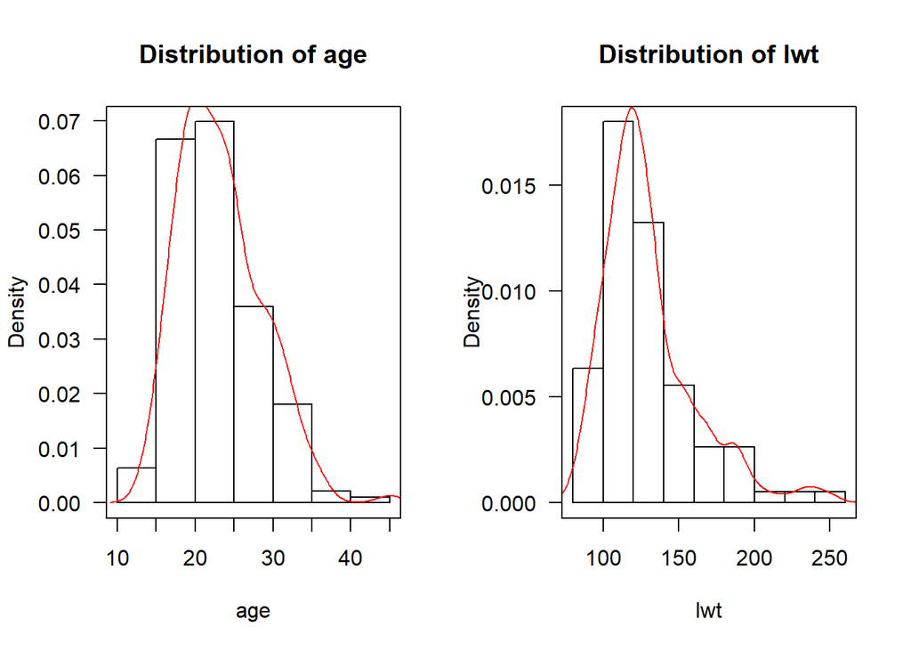

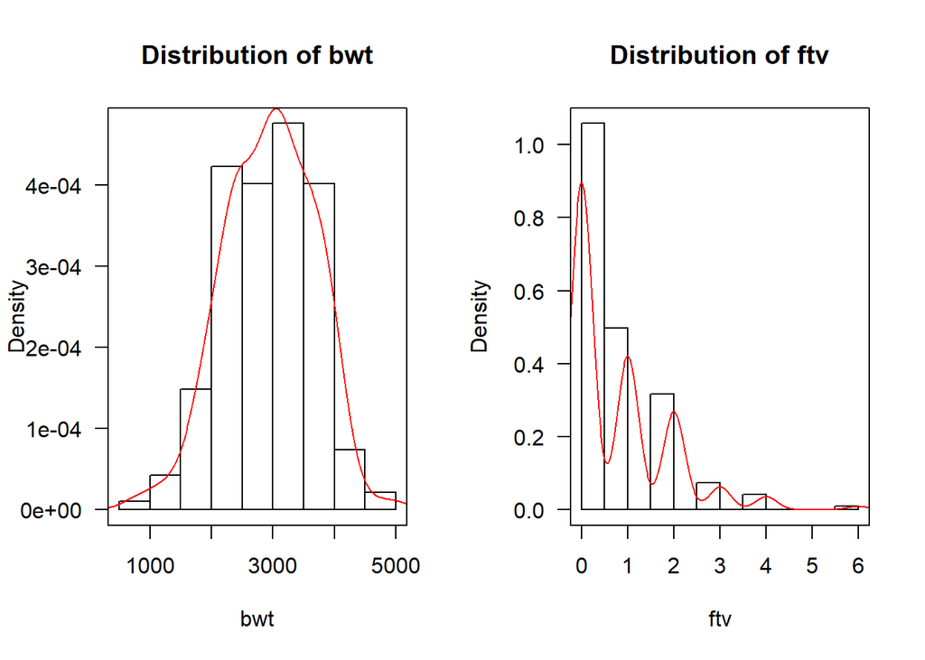

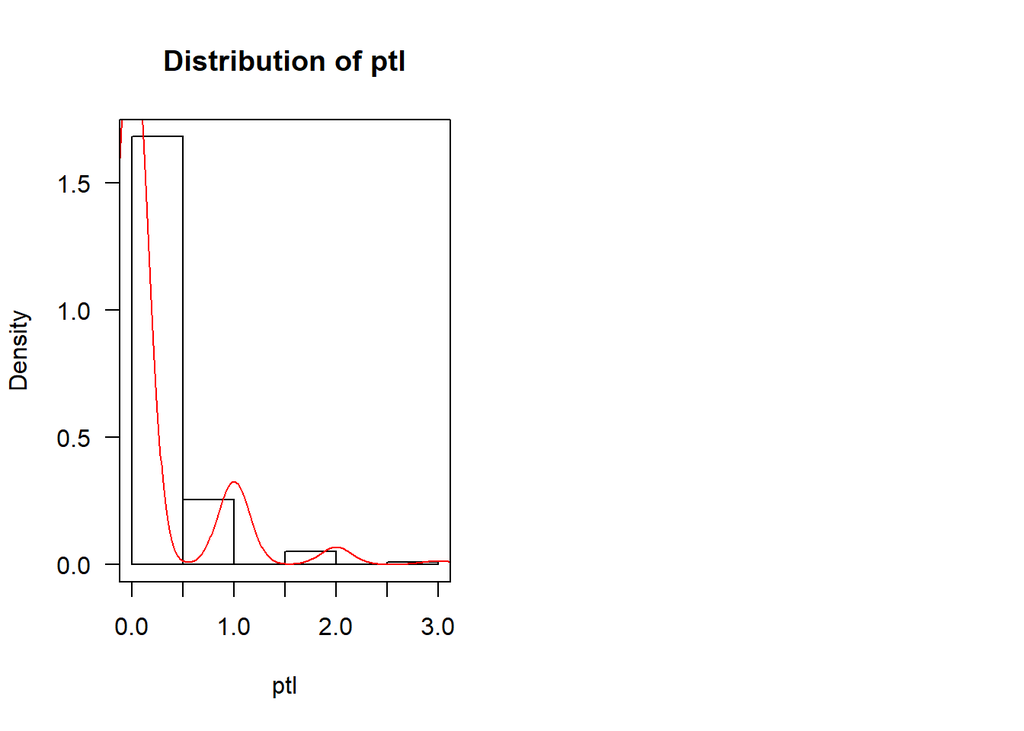

```r
par(mfrow = c(1, 2))
# Boucle sur toutes les variables quantitatives avec courbe de densité

for (var in vars_quanti) {
# 1. Tracer l'histogramme en mode "densité de probabilité" (prob = TRUE)
hist(birthwt[[var]],
main = paste("Distribution of", var), # Titre dynamique
xlab = var,                           # Nom de la variable sur l'axe X
ylab = "Density",                     # L'axe Y devient la Densité
las  = 1,  # Labels horizontaux
col  = "white",                       # Barres blanches
border = "black",                     # Contours noirs
prob = TRUE)                          # OBLIGATOIRE pour la densité
# 2. Calculer et superposer la courbe de densité
# na.rm = TRUE est crucial car il peut y avoir des NA dans la colonne 'nodes'
lines(density(birthwt[[var]], na.rm = TRUE),
col = "red",                         # Courbe en rouge pour le contraste
lwd = 1)                             # Épaisseur de la ligne
# 3. AJOUT DU CADRE AUTOUR DU GRAPHIQUE
box(col = "black", lwd = 1)
}
```

## **Descriptive analysis of categorical variables**

```r
data <- as.data.frame(birthwt)

library(gtsummary)

library(dplyr)


birthwt %>%
  # ── Recodage en facteurs avec labels explicites ──
  mutate(
    low   = factor(low,   levels = c(0, 1),
                   labels = c("≥ 2.5 kg", "< 2.5 kg (LBW)")),
    smoke = factor(smoke, levels = c(0, 1),
                   labels = c("Non-smoker", "Smoker")),
    ht    = factor(ht,    levels = c(0, 1),
                   labels = c("No", "Yes")),
    ui    = factor(ui,    levels = c(0, 1),
                   labels = c("No", "Yes")),
    race  = factor(race,  levels = c(1, 2, 3),
                   labels = c("White", "Black", "Other"))
  ) %>%
  # ── Sélection des variables ──
  select(low, smoke, ht, ui, race) %>%
  # ── Tableau stratifié par low ──
  tbl_summary(
    by          = low,
    statistic   = all_categorical() ~ "{n} ({p}%)",
    digits      = all_categorical() ~ list(0, 1),
    missing_text = "Missing",
    label        = list(
      smoke ~ "Smoking during pregnancy",
      ht    ~ "History of hypertension",
      ui    ~ "Uterine irritability",
      race  ~ "Race"
    )

  ) %>%
  # ── Libellés lisibles des variables ──
  modify_header(label = "**Characteristic**") %>%
  bold_labels()
```

| **Characteristic** | **≥ 2.5 kg** N = 130<sup>1</sup> | **< 2.5 kg (LBW)** N = 59<sup>1</sup> |
| --- | --- | --- |
| Smoking during pregnancy |  |  |
| Non-smoker | 86 (66.2%) | 29 (49.2%) |
| Smoker | 44 (33.8%) | 30 (50.8%) |
| History of hypertension | 5 (3.8%) | 7 (11.9%) |
| Uterine irritability | 14 (10.8%) | 14 (23.7%) |
| Race |  |  |
| White | 73 (56.2%) | 23 (39.0%) |
| Black | 15 (11.5%) | 11 (18.6%) |
| Other | 42 (32.3%) | 25 (42.4%) |

<sup>1</sup> n (%)

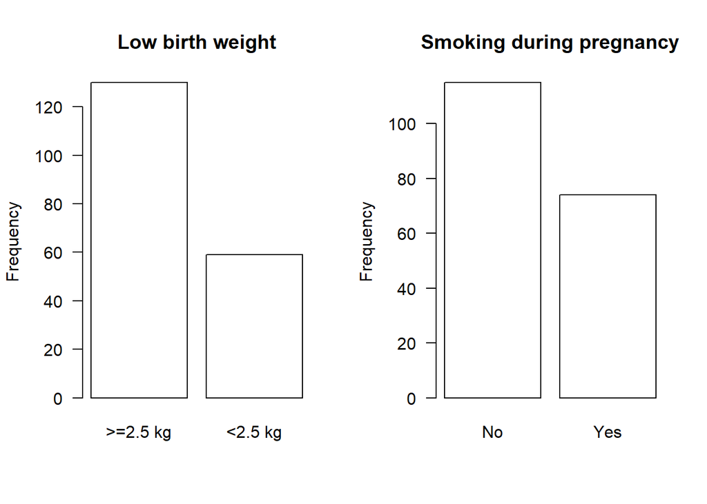

```r
par(mfrow = c(1, 2))

# ── 1. low (outcome binaire) ───────────────────────────
barplot(
  table(birthwt$low),
  ylab      = "Frequency",
  main      = "Low birth weight",
  names.arg = c(">=2.5 kg", "<2.5 kg"),
  col       = "white",
  border    = "black",
  las       = 1,
  cex.names = 1.0,
  cex.lab   = 1.0
)

# ── 2. smoke (binaire) ─────────────────────────────────
barplot(
  table(birthwt$smoke),
  ylab      = "Frequency",
  main      = "Smoking during pregnancy",
  names.arg = c("No", "Yes"),
  col       = "white",
  border    = "black",
  las       = 1,
  cex.names = 1.0,
  cex.lab   = 1.0
)
```

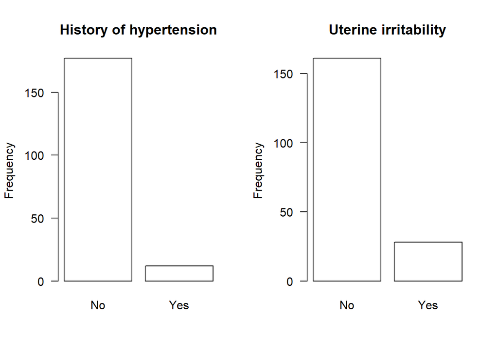

```r
# ── 3. ht (binaire) ────────────────────────────────────
barplot(
  table(birthwt$ht),
  ylab      = "Frequency",
  main      = "History of hypertension",
  names.arg = c("No", "Yes"),
  col       = "white",
  border    = "black",
  las       = 1,
  cex.names = 1.0,
  cex.lab   = 1.0
)

# ── 4. ui (binaire) ────────────────────────────────────
barplot(
  table(birthwt$ui),
  ylab      = "Frequency",
  main      = "Uterine irritability",
  names.arg = c("No", "Yes"),
  col       = "white",
  border    = "black",
  las       = 1,
  cex.names = 1.0,
  cex.lab   = 1.0
)
```

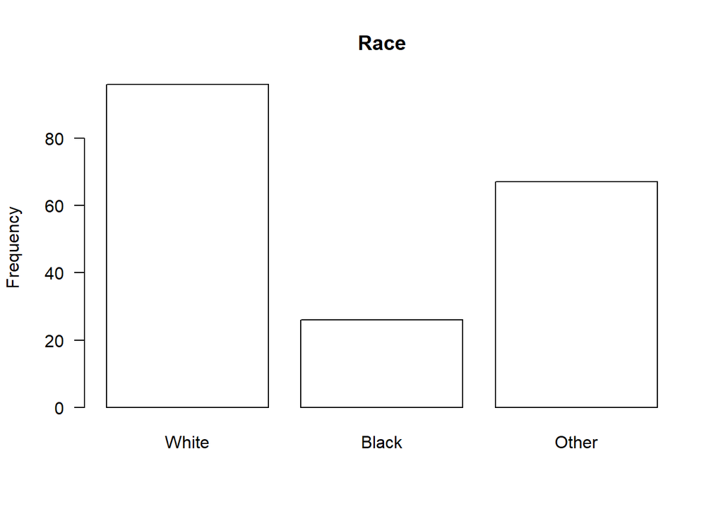

```r
# ── 5. race (3 modalités) ──────────────────────────────
barplot(
  table(birthwt$race),
  ylab      = "Frequency",
  main      = "Race",
  names.arg = c("White", "Black", "Other"),
  col       = "white",
  border    = "black",
  las       = 1,
  cex.names = 1.0,
  cex.lab   = 1.0
)
```

## **Missing data**

No missing data were observed in the dataset: all 189 observations were complete for every variable included in the analysis.

```r
tab_NA <- data.frame(
  Variables = names(birthwt),
  n_NA = colSums(is.na(birthwt)),
  percent_NA = round(colMeans(is.na(birthwt)) * 100, 2),
  row.names = NULL )

print(tab_NA)
```

```
##    Variables n_NA percent_NA
## 1        low    0          0
## 2        age    0          0
## 3        lwt    0          0
## 4       race    0          0
## 5      smoke    0          0
## 6        ptl    0          0
## 7         ht    0          0
## 8         ui    0          0
## 9        ftv    0          0
## 10       bwt    0          0
```

## **Statistical Modeling and Diagnostics**

The outcome `low` was frequent (31.2% of births), so OR from logistic regression would overestimate risk ratios.

A **log-binomial model** was therefore preferred to estimate risk ratios directly. However, it failed to converge.

A **modified Poisson regression with robust (sandwich) variance** was used instead, providing valid risk ratios with corrected standard errors.

Birth weight (`bwt`) was excluded from all models to avoid information leakage.

```r
#recoder en factor

# Binaires → facteurs avec labels
birthwt$low   <- factor(birthwt$low,   levels = c(0, 1),
                        labels = c("normal", "LBW"))
birthwt$smoke <- factor(birthwt$smoke, levels = c(0, 1),
                        labels = c("non-smoker", "smoker"))
birthwt$ht    <- factor(birthwt$ht,    levels = c(0, 1),
                        labels = c("no", "yes"))
birthwt$ui    <- factor(birthwt$ui,    levels = c(0, 1),
                        labels = c("no", "yes"))

birthwt$race  <- factor(birthwt$race,  levels = c(1, 2, 3),
                        labels = c("white", "black", "other"))
```

```r
library(sandwich)

library(lmtest)

# Ajustement du modèle de Poisson modifié
mod_poisson <- glm(low ~ age + lwt + factor(race) + smoke + ptl + ht + ui + ftv,
                   family = poisson(link = "log"), data = data)
```

# **Results**

- History of hypertension was the strongest predictor: mothers with a history of hypertension had a risk of low birth weight nearly three times that of mothers without hypertension (RR = 2.86; 95% CI: 1.69–4.84).
- Smoking during pregnancy was associated with an 80% increase in risk (RR = 1.80; 95% CI: 1.19–2.72).
- Race was also significantly associated with the outcome. Compared with white mothers, black mothers had a more than twofold increased risk (RR = 2.27; 95% CI: 1.31–3.93), and mothers of other racial origins had a 76% increased risk (RR = 1.76; 95% CI: 1.10–2.81).
- The remaining variables were not statistically significant: maternal age (RR = 0.98; 95% CI: 0.94–1.02), number of previous premature labours (RR = 1.31; 95% CI: 0.95–1.81), uterine irritability (RR = 1.55; 95% CI: 0.93–2.60), and number of physician visits in the first trimester (RR = 1.06; 95% CI: 0.87–1.29).

```r
# Calcul des erreurs types robustes (Méthode de Zou)
cov_robuste <- vcovHC(mod_poisson, type = "HC0")
std_err_robust <- sqrt(diag(cov_robuste))

# tableau des Risques Relatifs (RR)

coefficients <- coef(mod_poisson)

tableau_final <- data.frame(
  RR = exp(coefficients),
  IC_95_inf = exp(coefficients - 1.96 * std_err_robust),
  IC_95_sup = exp(coefficients + 1.96 * std_err_robust)
)

# Affichage du tableau dans votre rapport
print(tableau_final)
```

```
##                      RR IC_95_inf IC_95_sup
## (Intercept)   0.6706343 0.1760870 2.5541377
## age           0.9791015 0.9397402 1.0201114
## lwt           0.9905226 0.9823940 0.9987186
## factor(race)2 2.2668274 1.3091289 3.9251343
## factor(race)3 1.7556550 1.0972544 2.8091247
## smoke         1.8008794 1.1901654 2.7249713
## ptl           1.3115034 0.9505001 1.8096170
## ht            2.8576388 1.6861872 4.8429377
## ui            1.5545674 0.9291493 2.6009598
## ftv           1.0583316 0.8673944 1.2912993
```

# **Conclusion**

The analysis identified history of hypertension, smoking during pregnancy, and race as independent risk factors for low birth weight, with hypertension showing the strongest association.

These findings are consistent with the established literature on low birth weight and highlight hypertension and smoking as priority targets for prevention.